# Proteomics data analysis: heart

Lieven Clement

statOmics, Ghent University (https://statomics.github.io)

# 1 Background

Researchers have assessed the proteome in different regions of the heart for 3 patients (identifiers 3, 4, and 8). For each patient they sampled the left atrium (LA), right atrium (RA), left ventricle (LV) and the right ventricle (RV). The data are a small subset of the public dataset PXD006675 on PRIDE.

Suppose that researchers are mainly interested in comparing the ventricular to the atrial proteome. Particularly, they would like to compare the left atrium to the left ventricle, the right atrium to the right ventricle, the average ventricular vs atrial proteome and if ventricular vs atrial proteome shifts differ between left and right heart region.

# 2 Data

We first import the peptides.txt file. This is the file that contains your peptide-level intensities. For a MaxQuant search [6], this peptides.txt file can be found by default in the “path_to_raw_files/combined/txt/” folder from the MaxQuant output, with “path_to_raw_files” the folder where raw files were saved. In this tutorial, we will use a MaxQuant peptides file from MaxQuant that can be found in the data tree of the SGA2020 github repository https://github.com/statOmics/SGA2020/tree/data/quantification/heart .

To import the data we use the `QFeatures` package.

We generate the object peptideRawFile with the path to the peptideRaws.txt file. Using the `grepEcols` function, we find the columns that contain the expression data of the peptideRaws in the peptideRaws.txt file.

```r
library(tidyverse)
library(limma)
library(QFeatures)
library(msqrob2)
library(plotly)

peptidesFile <- "https://raw.githubusercontent.com/statOmics/SGA2020/data/quantification/heart/peptides.txt"

ecols <- MSnbase::grepEcols(
  peptidesFile,
  "Intensity ",
  split = "\t")

pe <- readQFeatures(
  table = peptidesFile,
  fnames = 1,
  ecol = ecols,
  name = "peptideRaw", sep="\t")

pe
```

```
## An instance of class QFeatures containing 1 assays:
##  [1] peptideRaw: SummarizedExperiment with 31319 rows and 12 columns
```

```r
pe[["peptideRaw"]]
```

```
## class: SummarizedExperiment
## dim: 31319 12
## metadata(0):
## assays(1): ''
## rownames(31319): AAAAAAAAAK AAAAAAAAEQQSSNGPVK ... YYTPVPCESATAK
##   YYTYLIMNK
## rowData names(91): Sequence N.term.cleavage.window ...
##   Oxidation..M..site.IDs MS.MS.Count
## colnames(12): Intensity.LA3 Intensity.LA4 ... Intensity.RV4
##   Intensity.RV8
## colData names(0):
```

We will make use from data wrangling functionalities from the tidyverse package. The %>% operator allows us to pipe the output of one function to the next function.

```r
colData(pe)$location <- substr(
  colnames(pe[["peptideRaw"]]),
  11,
  11) %>%
  unlist %>%
  as.factor

colData(pe)$tissue <- substr(
    colnames(pe[["peptideRaw"]]),
    12,
    12) %>%
    unlist %>%
    as.factor

colData(pe)$patient <- substr(
  colnames(pe[["peptideRaw"]]),
  13,
  13) %>%
  unlist %>%
  as.factor
```

We calculate how many non zero intensities we have per peptide and this will be useful for filtering.

```r
rowData(pe[["peptideRaw"]])$nNonZero <- rowSums(assay(pe[["peptideRaw"]]) > 0)
```

Peptides with zero intensities are missing peptides and should be represent with a `NA` value rather than `0`.

```r
pe <- zeroIsNA(pe, "peptideRaw") # convert 0 to NA
```

## 2.1 Data exploration

We can inspect the missingness in our data with the `plotNA()` function provided with `MSnbase`. 63% of all peptide intensities are missing and for some peptides we do not even measure a signal in any sample. The missingness is similar across samples.

[figure not shown]

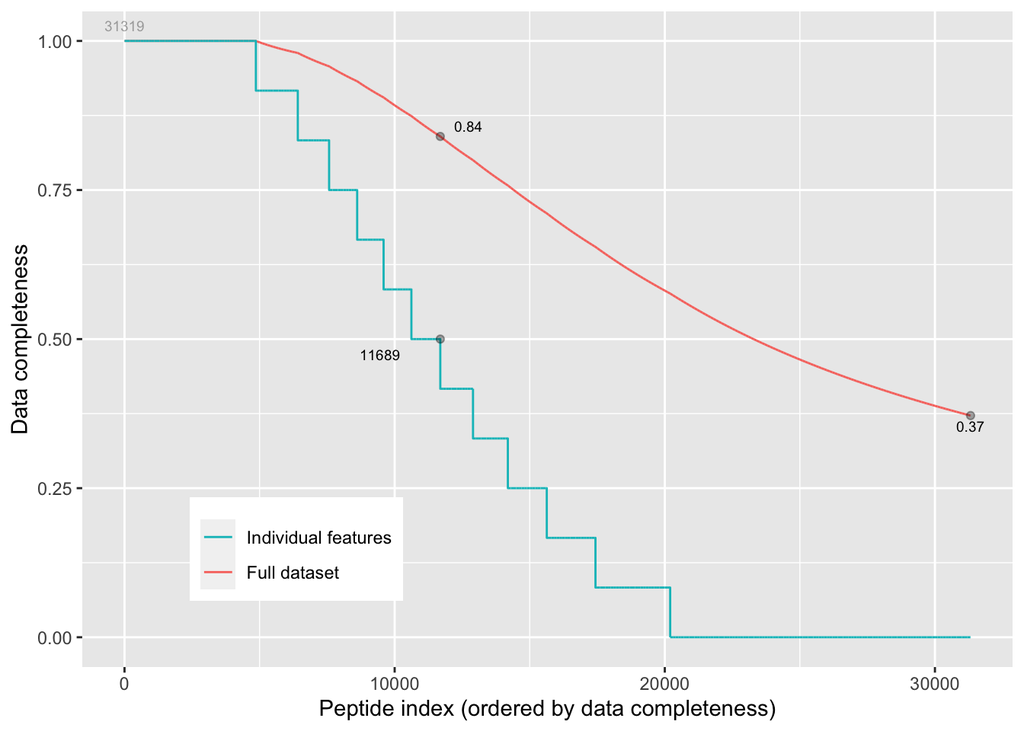

```r
MSnbase::plotNA(assay(pe[["peptideRaw"]])) +
  xlab("Peptide index (ordered by data completeness)")
```

# 3 Preprocessing

This section preforms standard preprocessing for the peptide data. This include log transformation, filtering and summarisation of the data.

## 3.1 Log transform the data

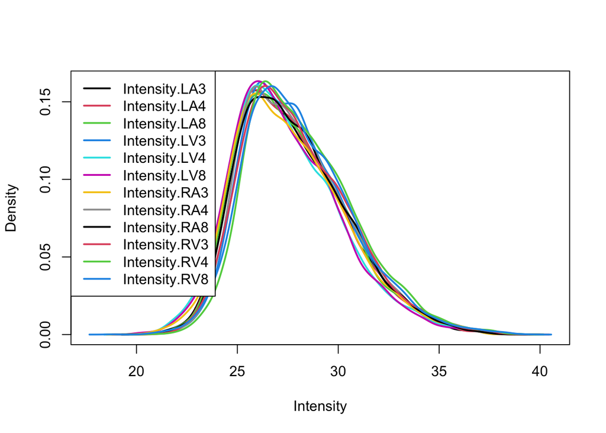

```r
pe <- logTransform(pe, base = 2, i = "peptideRaw", name = "peptideLog")
limma::plotDensities(assay(pe[["peptideLog"]]))
```

## 3.2 Filtering

### 3.2.1 Handling overlapping protein groups

In our approach a peptide can map to multiple proteins, as long as there is none of these proteins present in a smaller subgroup.

```r
pe[["peptideLog"]] <-
 pe[["peptideLog"]][rowData(pe[["peptideLog"]])$Proteins
 %in% smallestUniqueGroups(rowData(pe[["peptideLog"]])$Proteins),]
```

### 3.2.2 Remove reverse sequences (decoys) and contaminants

We now remove the contaminants, peptides that map to decoy sequences, and proteins which were only identified by peptides with modifications.

First look to the names of the variables for the peptide features

```r
pe[["peptideLog"]] %>%
  rowData %>%
  names
```

```
##  [1] "Sequence"                "N.term.cleavage.window"
##  [3] "C.term.cleavage.window"  "Amino.acid.before"
##  [5] "First.amino.acid"        "Second.amino.acid"
##  [7] "Second.last.amino.acid"  "Last.amino.acid"
##  [9] "Amino.acid.after"        "A.Count"
## [11] "R.Count"                 "N.Count"
## [13] "D.Count"                 "C.Count"
## [15] "Q.Count"                 "E.Count"
## [17] "G.Count"                 "H.Count"
## [19] "I.Count"                 "L.Count"
## [21] "K.Count"                 "M.Count"
## [23] "F.Count"                 "P.Count"
## [25] "S.Count"                 "T.Count"
## [27] "W.Count"                 "Y.Count"
## [29] "V.Count"                 "U.Count"
```

[output cut: 31 more lines]

No information on decoys.

```r
pe[["peptideLog"]] <- pe[["peptideLog"]][rowData(pe[["peptideLog"]])$
Potential.contaminant != "+", ]
```

### 3.2.3 Remove peptides of proteins that were only identified with modified peptides

I will skip this step for the moment. Large protein groups file needed for this.

### 3.2.4 Drop peptides that were only identified in one sample

We keep peptides that were observed at last twice.

```r
pe[["peptideLog"]] <- pe[["peptideLog"]][rowData(pe[["peptideLog"]])$nNonZero >= 2, ]
nrow(pe[["peptideLog"]])
```

```
## [1] 17432
```

We keep 17432 peptides after filtering.

## 3.3 Quantile normalize the data

```r
pe <- normalize(pe, i = "peptideLog", method = "quantiles", name = "peptideNorm")
```

## 3.4 Explore quantile normalized data

After quantile normalisation the density curves for all samples coincide.

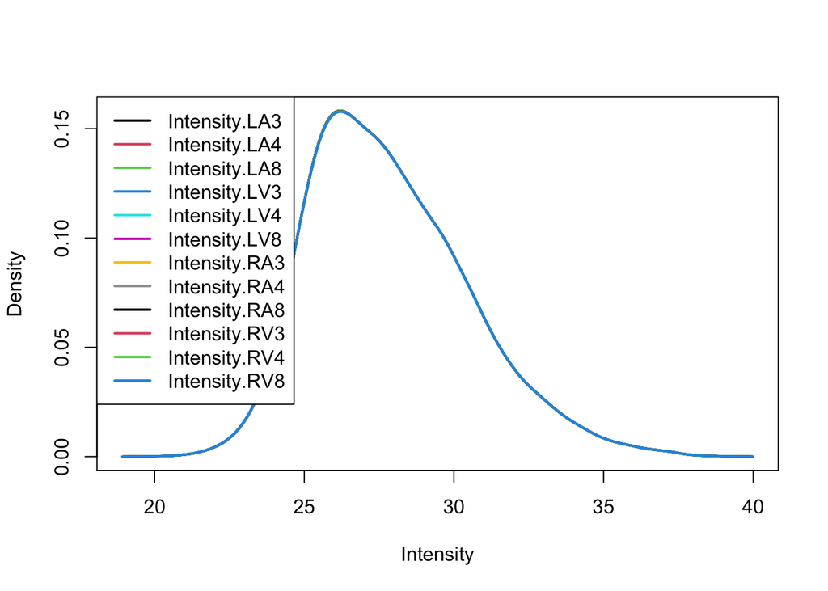

```r
limma::plotDensities(assay(pe[["peptideNorm"]]))
```

This is more clearly seen is a boxplot.

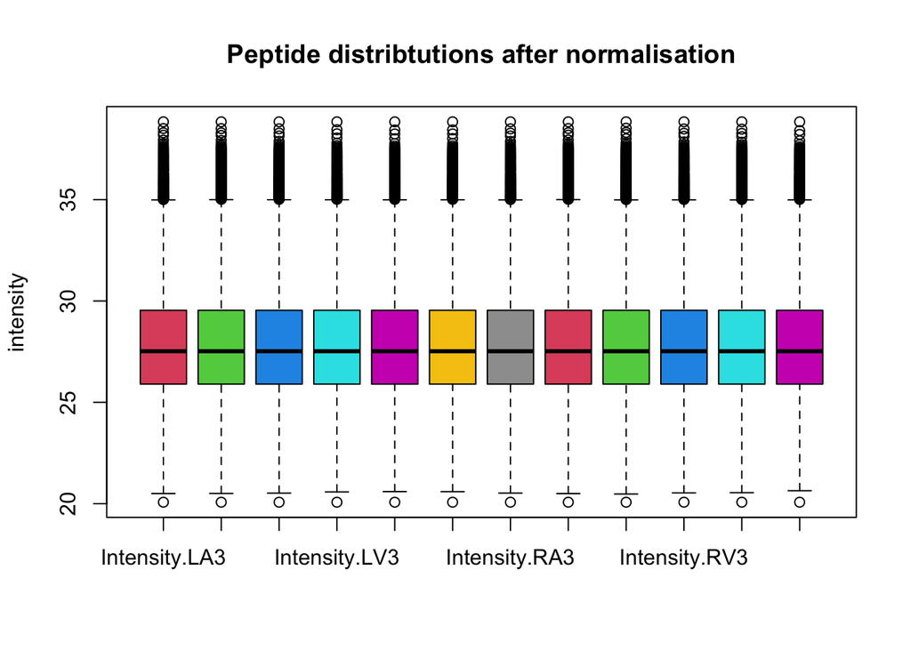

```r
boxplot(assay(pe[["peptideNorm"]]), col = palette()[-1],
       main = "Peptide distribtutions after normalisation", ylab = "intensity")
```

We can visualize our data using a Multi Dimensional Scaling plot, eg. as provided by the `limma` package.

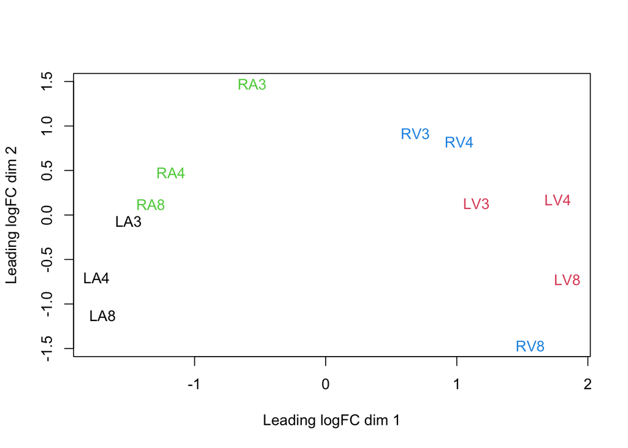

```r
limma::plotMDS(assay(pe[["peptideNorm"]]),
  col = colData(pe)$location:colData(pe)$tissue %>%
    as.numeric,
  labels = colData(pe) %>%
    rownames %>%
    substr(start = 11, stop = 13)
  )
```

The first axis in the plot is showing the leading log fold changes (differences on the log scale) between the samples.

## 3.5 Summarization to protein level

We use robust summarization in aggregateFeatures. This is the default workflow of aggregateFeatures so you do not have to specifiy the argument `fun`. However, because we compare methods we have included the `fun` argument to show the summarization method explicitely.

```r
pe <- aggregateFeatures(pe,
 i = "peptideNorm",
 fcol = "Proteins",
 na.rm = TRUE,
 name = "proteinRobust",
 fun = MsCoreUtils::robustSummary)
```

```
## Your quantitative and row data contain missing values. Please read the
## relevant section(s) in the aggregateFeatures manual page regarding the
## effects of missing values on data aggregation.
```

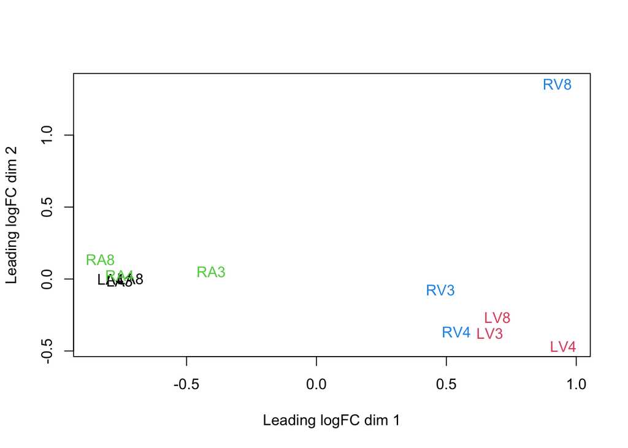

```r
plotMDS(assay(pe[["proteinRobust"]]),
  col = colData(pe)$location:colData(pe)$tissue %>%
    as.numeric,
  labels = colData(pe) %>%
    rownames %>%
    substr(start = 11, stop = 13)
)
```

# 4 Data Analysis

## 4.1 Estimation

We model the protein level expression values using `msqrob`. By default `msqrob2` estimates the model parameters using robust regression.

```r
pe <- msqrob(
  object = pe,
  i = "proteinRobust",
  formula = ~ location*tissue + patient)
```

## 4.2 Inference

First, we extract the parameter names of the model.

```r
getCoef(rowData(pe[["proteinRobust"]])$msqrobModels[[2]])
```

```
##       (Intercept)         locationR           tissueV          patient4
##       26.33779939        0.28826213        0.20946392        0.46536955
##          patient8 locationR:tissueV
##       -0.02608046       -0.05550111
```

```r
L <- makeContrast(
  c(
    "tissueV = 0",
    "tissueV + locationR:tissueV = 0",
    "tissueV + 0.5*locationR:tissueV = 0","locationR:tissueV = 0"),
  parameterNames =
    rowData(pe[["proteinRobust"]])$msqrobModels[[2]] %>%
    getCoef %>%
    names
  )


pe <- hypothesisTest(object = pe, i = "proteinRobust", contrast = L, overwrite=TRUE)
```

## 4.3 Evaluate results contrast $\log_2 FC_{V-A}^L$

### 4.3.1 Volcano-plot

[figure not shown]

```r
volcanoLeft <- ggplot(rowData(pe[["proteinRobust"]])$"tissueV + locationR:tissueV",
                 aes(x = logFC, y = -log10(pval), color = adjPval < 0.05)) +
 geom_point(cex = 2.5) +
 scale_color_manual(values = alpha(c("black", "red"), 0.5)) + theme_minimal()
volcanoLeft
```

### 4.3.2 Heatmap

We first select the names of the proteins that were declared signficant.

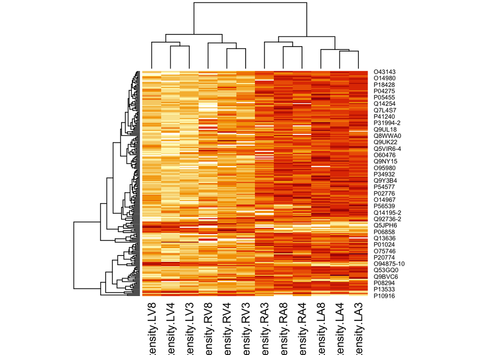

```r
sigNamesLeft <- rowData(pe[["proteinRobust"]])$tissueV %>%
 rownames_to_column("proteinRobust") %>%
 filter(adjPval<0.05) %>%
 pull(proteinRobust)
heatmap(assay(pe[["proteinRobust"]])[sigNamesLeft, ])
```

There are 211 proteins significantly differentially expressed at the 5% FDR level.

```r
rowData(pe[["proteinRobust"]])$tissueV %>%
  cbind(.,rowData(pe[["proteinRobust"]])$Protein.names) %>%
  na.exclude %>%
  filter(adjPval<0.05) %>%
  arrange(pval)  %>%
  knitr::kable(.)
```

|  | logFC | se | df | t | pval | adjPval | rowData(pe[[“proteinRobust”]])$Protein.names |
| --- | --- | --- | --- | --- | --- | --- | --- |
| P08590 | 7.566945 | 0.4227679 | 9.117912 | 17.898582 | 0.0000000 | 0.0000417 | Myosin light chain 3 |
| P12883 | 4.333125 | 0.3637861 | 9.255194 | 11.911187 | 0.0000006 | 0.0006480 | Myosin-7 |
| P10916 | 6.908674 | 0.5190748 | 7.385413 | 13.309594 | 0.0000020 | 0.0013463 | Myosin regulatory light chain 2, ventricular/cardiac muscle isoform |
| O75368 | -2.290376 | 0.2718512 | 9.251939 | -8.425109 | 0.0000123 | 0.0046575 | SH3 domain-binding glutamic acid-rich-like protein |
| P46821 | -2.182822 | 0.2654404 | 9.385413 | -8.223396 | 0.0000137 | 0.0046575 | Microtubule-associated protein 1B;MAP1B heavy chain;MAP1 light chain LC1 |
| Q6UWY5 | -3.253229 | 0.3888996 | 9.170135 | -8.365215 | 0.0000138 | 0.0046575 | Olfactomedin-like protein 1 |
| Q8N474 | -3.304647 | 0.3784419 | 7.847514 | -8.732243 | 0.0000261 | 0.0070102 | Secreted frizzled-related protein 1 |
| O95865 | -2.158932 | 0.2871753 | 9.385413 | -7.517818 | 0.0000288 | 0.0070102 | N(G),N(G)-dimethylarginine dimethylaminohydrolase 2 |
| Q9ULL5-3 | -3.386308 | 0.3993822 | 7.893242 | -8.478865 | 0.0000311 | 0.0070102 | Proline-rich protein 12 |
| P02452 | -3.226193 | 0.4112622 | 8.367424 | -7.844614 | 0.0000392 | 0.0070838 | Collagen alpha-1(I) chain |
| O94875-10 | 2.321238 | 0.3122508 | 8.958355 | 7.433891 | 0.0000406 | 0.0070838 | Sorbin and SH3 domain-containing protein 2 |
| Q16647 | -2.787698 | 0.3824272 | 9.156725 | -7.289485 | 0.0000422 | 0.0070838 | Prostacyclin synthase |
| P29622 | -2.114870 | 0.2991501 | 9.385413 | -7.069595 | 0.0000474 | 0.0070838 | Kallistatin |
| P14854 | 2.300663 | 0.3037112 | 8.346841 | 7.575168 | 0.0000514 | 0.0070838 | Cytochrome c oxidase subunit 6B1 |
| P05546 | -1.915671 | 0.2708975 | 9.198639 | -7.071573 | 0.0000523 | 0.0070838 | Heparin cofactor 2 |
| P21810 | -3.380254 | 0.4548500 | 8.304055 | -7.431580 | 0.0000609 | 0.0077217 | Biglycan |
| P36955 | -2.323620 | 0.3325722 | 8.456893 | -6.986813 | 0.0000872 | 0.0097521 | Pigment epithelium-derived factor |
| P23083 | -4.274293 | 0.5581240 | 7.385413 | -7.658322 | 0.0000912 | 0.0097521 | Ig heavy chain V-I region V35 |
| P13533 | -4.313925 | 0.6516590 | 9.115028 | -6.619911 | 0.0000915 | 0.0097521 | Myosin-6 |
| Q15113 | -2.755021 | 0.4253583 | 9.188121 | -6.476942 | 0.0001043 | 0.0097521 | Procollagen C-endopeptidase enhancer 1 |
| Q9UBG0 | -2.576210 | 0.3963719 | 9.131671 | -6.499476 | 0.0001044 | 0.0097521 | C-type mannose receptor 2 |
| P00325 | -2.108814 | 0.3251595 | 9.141096 | -6.485476 | 0.0001057 | 0.0097521 | Alcohol dehydrogenase 1B |
| P07451 | -1.841539 | 0.2910138 | 9.385413 | -6.328012 | 0.0001136 | 0.0100264 | Carbonic anhydrase 3 |
| P51888 | -3.199549 | 0.4165978 | 6.959924 | -7.680186 | 0.0001217 | 0.0102934 | Prolargin |
| P24844 | -2.551801 | 0.4140400 | 9.330669 | -6.163176 | 0.0001427 | 0.0112127 | Myosin regulatory light polypeptide 9 |
| Q53GQ0 | -2.430853 | 0.3948274 | 9.334954 | -6.156748 | 0.0001436 | 0.0112127 | Very-long-chain 3-oxoacyl-CoA reductase |
| Q06828 | -4.209189 | 0.6775919 | 9.003303 | -6.211983 | 0.0001564 | 0.0116347 | Fibromodulin |
| Q8TBQ9 | -2.761806 | 0.4223033 | 8.170120 | -6.539863 | 0.0001643 | 0.0116347 | Protein kish-A |
| P51884 | -2.402234 | 0.3614104 | 7.936878 | -6.646831 | 0.0001672 | 0.0116347 | Lumican |
| P35442 | -2.334260 | 0.3655617 | 8.385413 | -6.385405 | 0.0001735 | 0.0116347 | Thrombospondin-2 |

[output cut: 181 more lines]

## 4.4 Evaluate results contrast $\log_2 FC_{V-A}^R$

### 4.4.1 Volcano-plot

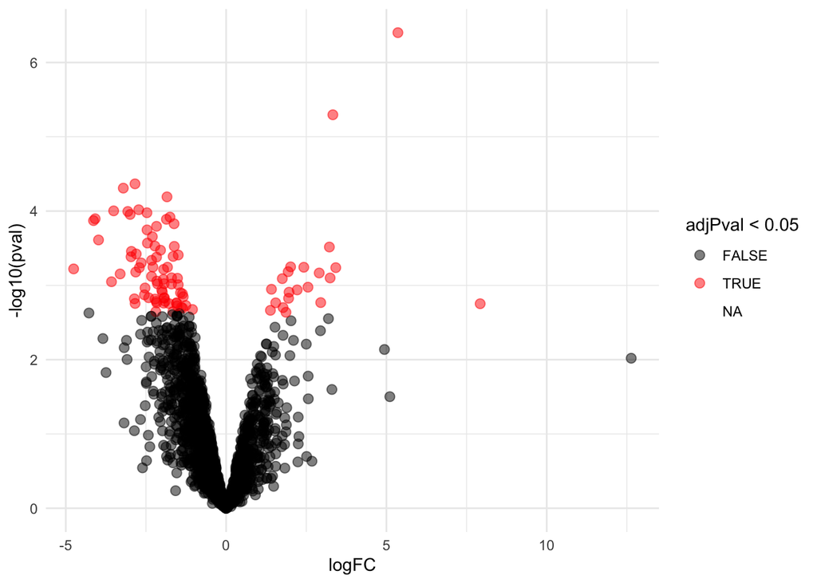

```r
volcanoRight <- ggplot(rowData(pe[["proteinRobust"]])$"tissueV + locationR:tissueV",
                 aes(x = logFC, y = -log10(pval), color = adjPval < 0.05)) +
 geom_point(cex = 2.5) +
 scale_color_manual(values = alpha(c("black", "red"), 0.5)) + theme_minimal()
volcanoRight
```

### 4.4.2 Heatmap

We first select the names of the proteins that were declared signficant.

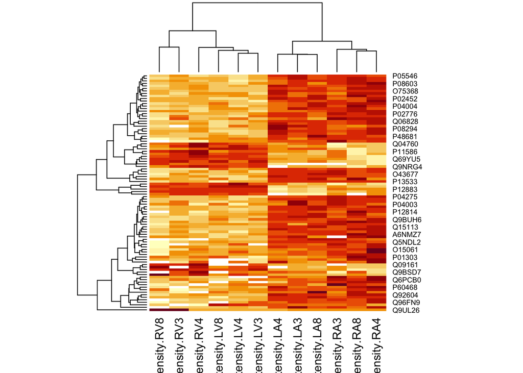

```r
sigNamesRight <- rowData(pe[["proteinRobust"]])$"tissueV + locationR:tissueV" %>%
 rownames_to_column("proteinRobust") %>%
 filter(adjPval<0.05) %>%
 pull(proteinRobust)
heatmap(assay(pe[["proteinRobust"]])[sigNamesRight, ])
```

There are 94 proteins significantly differentially expressed at the 5% FDR level.

```r
rowData(pe[["proteinRobust"]])$"tissueV + locationR:tissueV"  %>%
  cbind(.,rowData(pe[["proteinRobust"]])$Protein.names) %>%
  na.exclude %>%
  filter(adjPval<0.05) %>%
  arrange(pval) %>%
  knitr::kable(.)
```

|  | logFC | se | df | t | pval | adjPval | rowData(pe[[“proteinRobust”]])$Protein.names |
| --- | --- | --- | --- | --- | --- | --- | --- |
| P08590 | 5.358077 | 0.4191438 | 9.117912 | 12.783387 | 0.0000004 | 0.0008046 | Myosin light chain 3 |
| P06858 | 3.329246 | 0.3542730 | 9.218266 | 9.397404 | 0.0000051 | 0.0051277 | Lipoprotein lipase |
| P02776 | -2.841711 | 0.3443690 | 7.718405 | -8.251937 | 0.0000430 | 0.0194907 | Platelet factor 4;Platelet factor 4, short form |
| P35442 | -3.207091 | 0.4221143 | 8.385413 | -7.597683 | 0.0000491 | 0.0194907 | Thrombospondin-2 |
| O75368 | -1.844075 | 0.2686680 | 9.251939 | -6.863771 | 0.0000643 | 0.0194907 | SH3 domain-binding glutamic acid-rich-like protein |
| P54652 | -2.725246 | 0.4112417 | 9.007166 | -6.626871 | 0.0000959 | 0.0194907 | Heat shock-related 70 kDa protein 2 |
| Q9ULD0 | -3.507028 | 0.3938799 | 6.128068 | -8.903799 | 0.0000993 | 0.0194907 | 2-oxoglutarate dehydrogenase-like, mitochondrial |
| A6NMZ7 | -3.065958 | 0.4773591 | 9.385413 | -6.422751 | 0.0001012 | 0.0194907 | Collagen alpha-6(VI) chain |
| Q6UWY5 | -2.469667 | 0.3813094 | 9.170135 | -6.476806 | 0.0001053 | 0.0194907 | Olfactomedin-like protein 1 |
| P21810 | -2.994207 | 0.4377152 | 8.304055 | -6.840536 | 0.0001110 | 0.0194907 | Biglycan |
| P05546 | -1.750184 | 0.2755089 | 9.198639 | -6.352548 | 0.0001204 | 0.0194907 | Heparin cofactor 2 |
| P13533 | -4.083951 | 0.6439331 | 9.115028 | -6.342197 | 0.0001269 | 0.0194907 | Myosin-6 |
| P29622 | -1.862155 | 0.2991501 | 9.385413 | -6.224819 | 0.0001290 | 0.0194907 | Kallistatin |
| Q06828 | -4.135476 | 0.6523980 | 9.003303 | -6.338886 | 0.0001344 | 0.0194907 | Fibromodulin |
| P46821 | -1.622963 | 0.2654404 | 9.385413 | -6.114227 | 0.0001481 | 0.0200375 | Microtubule-associated protein 1B;MAP1B heavy chain;MAP1 light chain LC1 |
| P28066 | -2.170776 | 0.3390487 | 8.500773 | -6.402548 | 0.0001604 | 0.0203510 | Proteasome subunit alpha type-5 |
| Q9UGT4 | -2.466535 | 0.4090800 | 9.193722 | -6.029468 | 0.0001792 | 0.0213941 | Sushi domain-containing protein 2 |
| Q6PCB0 | -2.300792 | 0.3926118 | 9.198450 | -5.860221 | 0.0002211 | 0.0249365 | von Willebrand factor A domain-containing protein 1 |
| P35625 | -3.979204 | 0.6344156 | 7.962134 | -6.272235 | 0.0002447 | 0.0261405 | Metalloproteinase inhibitor 3 |
| P60468 | -2.454190 | 0.4052019 | 8.241407 | -6.056708 | 0.0002697 | 0.0268819 | Protein transport protein Sec61 subunit beta |
| Q15327 | -2.221783 | 0.3961366 | 9.280457 | -5.608627 | 0.0002957 | 0.0268819 | Ankyrin repeat domain-containing protein 1 |
| Q14764 | -1.616256 | 0.2901417 | 9.385413 | -5.570573 | 0.0002985 | 0.0268819 | Major vault protein |
| Q69YU5 | 3.220843 | 0.5625486 | 8.841525 | 5.725448 | 0.0003046 | 0.0268819 | Uncharacterized protein C12orf73 |
| Q9P2B2 | -2.045271 | 0.3731311 | 9.385413 | -5.481374 | 0.0003362 | 0.0281811 | Prostaglandin F2 receptor negative regulator |
| P48163 | -2.953929 | 0.4964480 | 7.960353 | -5.950127 | 0.0003486 | 0.0281811 | NADP-dependent malic enzyme |
| Q92930 | -2.803127 | 0.4638105 | 7.597170 | -6.043690 | 0.0003777 | 0.0281811 | Ras-related protein Rab-8B |
| P48681 | -1.493328 | 0.2771541 | 9.321612 | -5.388078 | 0.0003901 | 0.0281811 | Nestin |
| P01031 | -1.652659 | 0.2888520 | 8.183937 | -5.721472 | 0.0004077 | 0.0281811 | Complement C5;Complement C5 beta chain;Complement C5 alpha chain;C5a anaphylatoxin;Complement C5 alpha chain |
| O43677 | -2.965485 | 0.5101963 | 7.933870 | -5.812438 | 0.0004121 | 0.0281811 | NADH dehydrogenase [ubiquinone] 1 subunit C1, mitochondrial |
| P02775 | -2.169029 | 0.4075050 | 9.385413 | -5.322705 | 0.0004165 | 0.0281811 | Platelet basic protein;Connective tissue-activating peptide III;TC-2;Connective tissue-activating peptide III(1-81);Beta-thromboglobulin;Neutrophil-activating peptide 2(74);Neutrophil-activating pepti… |

[output cut: 64 more lines]

## 4.5 Evaluate results average contrast $\log_2 FC_{V-A}$

### 4.5.1 Volcano-plot

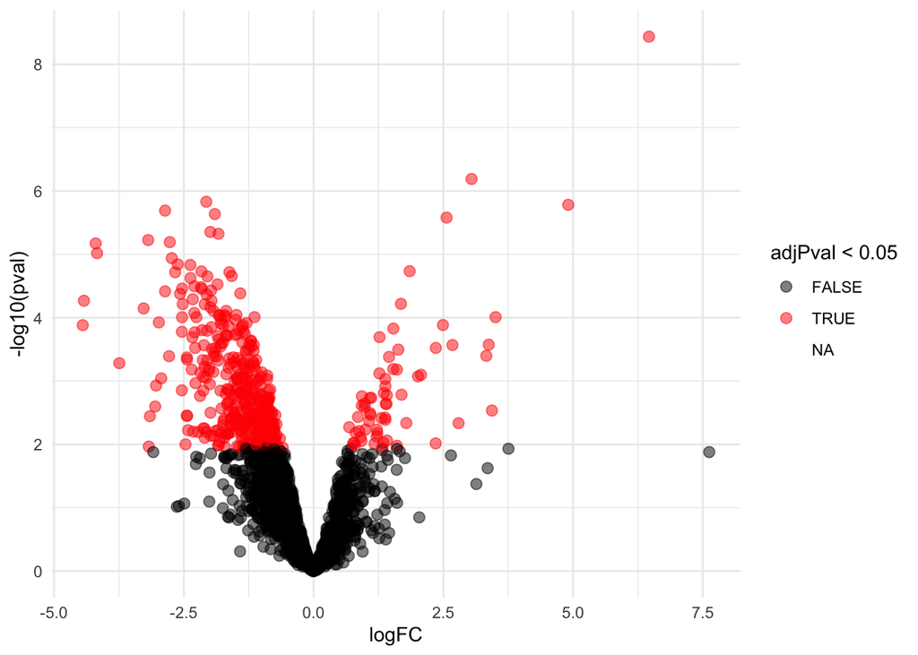

```r
volcanoAvg <- ggplot(rowData(pe[["proteinRobust"]])$"tissueV + 0.5 * locationR:tissueV",
                 aes(x = logFC, y = -log10(pval), color = adjPval < 0.05)) +
 geom_point(cex = 2.5) +
 scale_color_manual(values = alpha(c("black", "red"), 0.5)) + theme_minimal()
volcanoAvg
```

### 4.5.2 Heatmap

We first select the names of the proteins that were declared signficant.

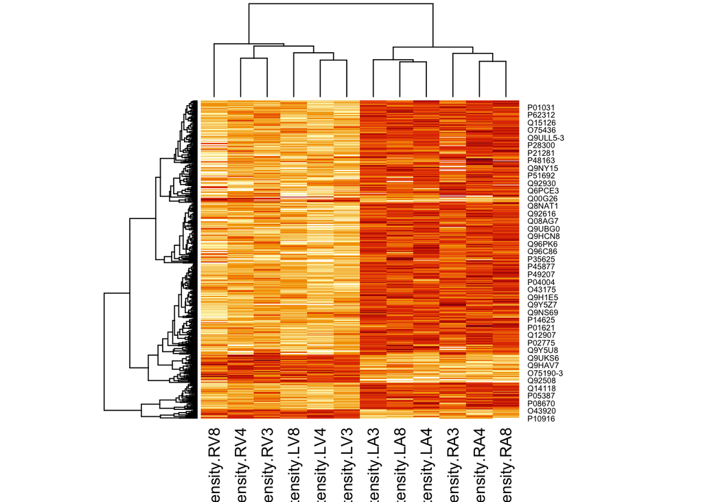

```r
sigNamesAvg <- rowData(pe[["proteinRobust"]])$"tissueV + 0.5 * locationR:tissueV" %>%
 rownames_to_column("proteinRobust") %>%
 filter(adjPval<0.05) %>%
 pull(proteinRobust)
heatmap(assay(pe[["proteinRobust"]])[sigNamesAvg, ])
```

There are 461 proteins significantly differentially expressed at the 5% FDR level.

```r
rowData(pe[["proteinRobust"]])$"tissueV + 0.5 * locationR:tissueV" %>%
  cbind(.,rowData(pe[["proteinRobust"]])$Protein.names) %>%
  na.exclude %>%
  filter(adjPval<0.05) %>%
  arrange(pval) %>%
  knitr::kable(.)
```

|  | logFC | se | df | t | pval | adjPval | rowData(pe[[“proteinRobust”]])$Protein.names |
| --- | --- | --- | --- | --- | --- | --- | --- |
| P08590 | 6.4625112 | 0.2976280 | 9.117912 | 21.713386 | 0.0000000 | 0.0000074 | Myosin light chain 3 |
| P12883 | 3.0427569 | 0.2557724 | 9.255194 | 11.896344 | 0.0000006 | 0.0006551 | Myosin-7 |
| O75368 | -2.0672256 | 0.1911057 | 9.251939 | -10.817185 | 0.0000015 | 0.0007617 | SH3 domain-binding glutamic acid-rich-like protein |
| P10916 | 4.9061329 | 0.3591470 | 7.385413 | 13.660515 | 0.0000017 | 0.0007617 | Myosin regulatory light chain 2, ventricular/cardiac muscle isoform |
| Q6UWY5 | -2.8614477 | 0.2723232 | 9.170135 | -10.507543 | 0.0000020 | 0.0007617 | Olfactomedin-like protein 1 |
| P46821 | -1.9028923 | 0.1876947 | 9.385413 | -10.138230 | 0.0000023 | 0.0007617 | Microtubule-associated protein 1B;MAP1B heavy chain;MAP1 light chain LC1 |
| P06858 | 2.5622451 | 0.2524054 | 9.218266 | 10.151307 | 0.0000026 | 0.0007617 | Lipoprotein lipase |
| P29622 | -1.9885126 | 0.2115311 | 9.385413 | -9.400570 | 0.0000044 | 0.0010675 | Kallistatin |
| P05546 | -1.8329275 | 0.1931907 | 9.198639 | -9.487658 | 0.0000047 | 0.0010675 | Heparin cofactor 2 |
| P21810 | -3.1872304 | 0.3151219 | 8.304055 | -10.114278 | 0.0000059 | 0.0011366 | Biglycan |
| P35442 | -2.7706752 | 0.2792024 | 8.385413 | -9.923538 | 0.0000064 | 0.0011366 | Thrombospondin-2 |
| P13533 | -4.1989377 | 0.4579673 | 9.115028 | -9.168640 | 0.0000067 | 0.0011366 | Myosin-6 |
| Q06828 | -4.1723327 | 0.4703068 | 9.003303 | -8.871513 | 0.0000096 | 0.0014958 | Fibromodulin |
| Q8N474 | -2.7331853 | 0.2795787 | 7.847514 | -9.776084 | 0.0000115 | 0.0016658 | Secreted frizzled-related protein 1 |
| P02452 | -2.6166150 | 0.2921724 | 8.367424 | -8.955722 | 0.0000144 | 0.0018663 | Collagen alpha-1(I) chain |
| Q9UGT4 | -2.3750749 | 0.2867846 | 9.193722 | -8.281739 | 0.0000147 | 0.0018663 | Sushi domain-containing protein 2 |
| O94875-10 | 1.8515322 | 0.2254187 | 8.958355 | 8.213746 | 0.0000184 | 0.0019441 | Sorbin and SH3 domain-containing protein 2 |
| Q16647 | -2.1609826 | 0.2677306 | 9.156725 | -8.071483 | 0.0000186 | 0.0019441 | Prostacyclin synthase |
| Q14764 | -1.6211158 | 0.2051612 | 9.385413 | -7.901669 | 0.0000191 | 0.0019441 | Major vault protein |
| A6NMZ7 | -2.6666436 | 0.3375438 | 9.385413 | -7.900140 | 0.0000192 | 0.0019441 | Collagen alpha-6(VI) chain |
| O95865 | -1.5774343 | 0.2030636 | 9.385413 | -7.768178 | 0.0000220 | 0.0020570 | N(G),N(G)-dimethylarginine dimethylaminohydrolase 2 |
| Q9P2B2 | -2.0463902 | 0.2638435 | 9.385413 | -7.756076 | 0.0000223 | 0.0020570 | Prostaglandin F2 receptor negative regulator |
| Q15113 | -2.3717647 | 0.3035044 | 9.188121 | -7.814597 | 0.0000237 | 0.0020912 | Procollagen C-endopeptidase enhancer 1 |
| P18428 | -1.8519938 | 0.2405365 | 9.013977 | -7.699428 | 0.0000298 | 0.0025169 | Lipopolysaccharide-binding protein |
| P02776 | -2.2952145 | 0.2665516 | 7.718405 | -8.610771 | 0.0000319 | 0.0025481 | Platelet factor 4;Platelet factor 4, short form |
| P24844 | -2.1677081 | 0.2920895 | 9.330669 | -7.421383 | 0.0000330 | 0.0025481 | Myosin regulatory light polypeptide 9 |
| Q9BW30 | -2.5325002 | 0.3361911 | 9.049210 | -7.532919 | 0.0000346 | 0.0025481 | Tubulin polymerization-promoting protein family member 3 |
| P54652 | -2.1555836 | 0.2857710 | 9.007166 | -7.543045 | 0.0000351 | 0.0025481 | Heat shock-related 70 kDa protein 2 |
| P00748 | -1.9760261 | 0.2655421 | 9.091376 | -7.441479 | 0.0000372 | 0.0025980 | Coagulation factor XII;Coagulation factor XIIa heavy chain;Beta-factor XIIa part 1;Coagulation factor XIIa light chain |
| O43677 | -2.8617874 | 0.3490622 | 7.933870 | -8.198503 | 0.0000384 | 0.0025980 | NADH dehydrogenase [ubiquinone] 1 subunit C1, mitochondrial |

[output cut: 431 more lines]

## 4.6 Interaction

### 4.6.1 Volcano-plot

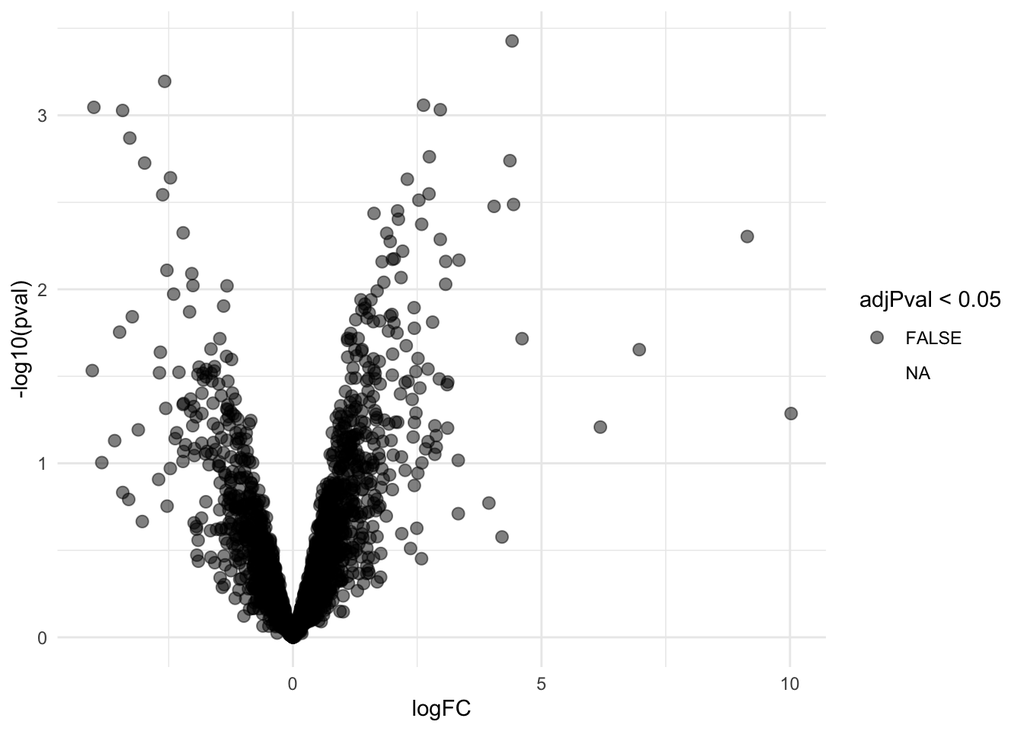

```r
volcanoInt <- ggplot(rowData(pe[["proteinRobust"]])$"locationR:tissueV",
                 aes(x = logFC, y = -log10(pval), color = adjPval < 0.05)) +
 geom_point(cex = 2.5) +
 scale_color_manual(values = alpha(c("black", "red"), 0.5)) + theme_minimal()
volcanoInt
```

### 4.6.2 Heatmap

There were no genes significant at the 5% FDR level. We return the top 25 genes.

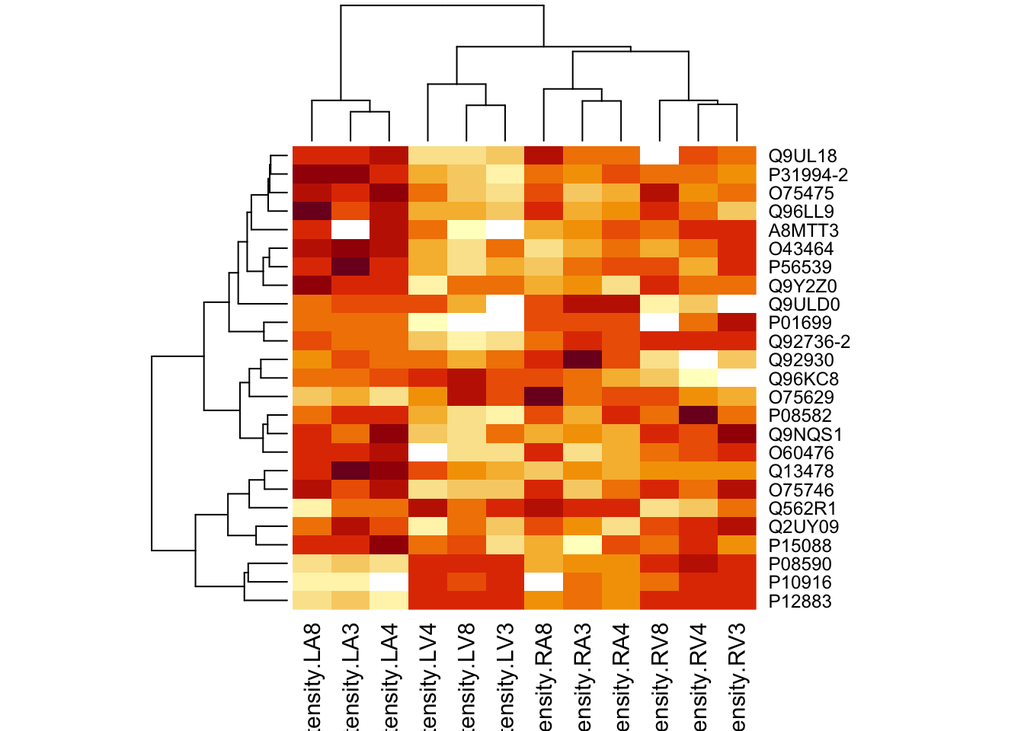

```r
sigNamesInt <- rowData(pe[["proteinRobust"]])$"locationR:tissueV" %>%
 rownames_to_column("proteinRobust") %>%
 filter(adjPval<0.05) %>%
 pull(proteinRobust)
hlp <- order((rowData(pe[["proteinRobust"]])$"locationR:tissueV")[,"adjPval"])[1:25]
heatmap(assay(pe[["proteinRobust"]])[hlp, ])
```

There are 0 proteins significantly differentially expressed at the 5% FDR level.

```r
rowData(pe[["proteinRobust"]])$"locationR:tissueV" %>%
  cbind(.,rowData(pe[["proteinRobust"]])$Protein.names) %>%
  na.exclude %>%
  filter(adjPval<0.05) %>%
  arrange(pval)
```

```
## [1] logFC
## [2] se
## [3] df
## [4] t
## [5] pval
## [6] adjPval
## [7] rowData(pe[["proteinRobust"]])$Protein.names
## <0 rows> (or 0-length row.names)
```

# 5 Large difference in number of proteins that are returned

Note, that much more proteins are returned significant for average contrast ($\log_2 FC_{V-A}$) as compared to contrast for assessing the fold change between ventriculum and atrium left and right. The power for the average contrast is larger than for the contrast left or right because the log2 FC can be estimated with higher precision.

For none of the proteins the interaction was significant (change in log2 FC between ventriculum and atrium in the right vs the left heart region). The power for the interaction is typically low.

## 5.1 Reason

Part of variance covariance matrix of model parameters due to design:

```r
X <- model.matrix(~ location*tissue + patient, colData(pe))
covarUnscaled <- solve(t(X) %*% X)
```

Variance of contrasts (diagonal elements) due to design

```r
varContrasts <- t(L)%*%covarUnscaled%*%L %>%
  diag
varContrasts
```

```
##                           tissueV       tissueV + locationR:tissueV
##                         0.6666667                         0.6666667
## tissueV + 0.5 * locationR:tissueV                 locationR:tissueV
##                         0.3333333                         1.3333333
```

```r
sqrt(varContrasts)
```

```
##                           tissueV       tissueV + locationR:tissueV
##                         0.8164966                         0.8164966
## tissueV + 0.5 * locationR:tissueV                 locationR:tissueV
##                         0.5773503                         1.1547005
```

So it is clear that the standard error of the log2 FC left and right is the same. That of the average contrast is a factor $\sqrt{2}$ smaller! Indeed, we use double the number of samples to estimate it!

```r
varContrasts[3]/varContrasts[2]
```

```
## tissueV + 0.5 * locationR:tissueV
##                               0.5
```

```r
sqrt(varContrasts)[3]/sqrt(varContrasts)[2]
```

```
## tissueV + 0.5 * locationR:tissueV
##                         0.7071068
```

```r
1/sqrt(2)
```

```
## [1] 0.7071068
```

The standard error of the interaction is a factor $\sqrt{2}$ larger than that of the main effects!

```r
varContrasts[4]/varContrasts[2]
```

```
## locationR:tissueV
##                 2
```

```r
sqrt(varContrasts)[4]/sqrt(varContrasts)[2]
```

```
## locationR:tissueV
##          1.414214
```

```r
sqrt(2)
```

```
## [1] 1.414214
```

## 5.2 Msqrob

This is not the case for the standard errors of protein 2???

```r
rowData(pe[["proteinRobust"]])$"tissueV"[2,]
```

```
##            logFC        se       df        t      pval   adjPval
## A0PJW6 0.2094639 0.5601628 7.914824 0.373934 0.7182716 0.8351039
```

```r
rowData(pe[["proteinRobust"]])$"tissueV + locationR:tissueV"[2,]
```

```
##            logFC        se       df        t     pval   adjPval
## A0PJW6 0.1539628 0.6164233 7.914824 0.249768 0.809127 0.8985718
```

```r
rowData(pe[["proteinRobust"]])$"tissueV + 0.5 * locationR:tissueV"[2,]
```

```
##            logFC        se       df         t      pval   adjPval
## A0PJW6 0.1817134 0.4153001 7.914824 0.4375472 0.6734084 0.7736384
```

```r
rowData(pe[["proteinRobust"]])$"locationR:tissueV"[2,]
```

```
##              logFC        se       df          t      pval   adjPval
## A0PJW6 -0.05550111 0.8352387 7.914824 -0.0664494 0.9486679 0.9936311
```

Because msqrob is using robust regression to assess DE!

```r
pe %>%
  colData %>%
  as_tibble %>%
  mutate(w=getModel(rowData(pe[["proteinRobust"]])$msqrobModels[[2]])$w)
```

```
## # A tibble: 12 x 4
##    location tissue patient     w
##    <fct>    <fct>  <fct>   <dbl>
##  1 L        A      3       0.952
##  2 L        A      4       1
##  3 L        A      8       0.663
##  4 L        V      3       1
##  5 L        V      4       1
##  6 L        V      8       1
##  7 R        A      3       1
##  8 R        A      4       1
##  9 R        A      8       1
## 10 R        V      3       0.481
## 11 R        V      4       1
## 12 R        V      8       0.434
```

For protein 2 the samples at the left and right side have different weights!

### 5.2.1 Part of standard error due to design:

```r
covUnscaledRobust <- solve(
  t(X) %*%
  diag(
    getModel(rowData(pe[["proteinRobust"]])$msqrobModels[[2]])$w) %*% X)

varContrastsRobust <- t(L)%*%covUnscaledRobust%*%L %>%
  diag
varContrastsRobust
```

```
##                           tissueV       tissueV + locationR:tissueV
##                         0.7187863                         0.8704210
## tissueV + 0.5 * locationR:tissueV                 locationR:tissueV
##                         0.3950893                         1.5980575
```

```r
sqrt(varContrastsRobust)
```

```
##                           tissueV       tissueV + locationR:tissueV
##                         0.8478127                         0.9329636
## tissueV + 0.5 * locationR:tissueV                 locationR:tissueV
##                         0.6285613                         1.2641430
```

### 5.2.2 Standard errors Contrasts

```r
sqrt(varContrastsRobust) * getSigmaPosterior(rowData(pe[["proteinRobust"]])$msqrobModels[[2]])
```

```
##                           tissueV       tissueV + locationR:tissueV
##                         0.5601628                         0.6164233
## tissueV + 0.5 * locationR:tissueV                 locationR:tissueV
##                         0.4153001                         0.8352387
```

```r
rowData(pe[["proteinRobust"]])$"tissueV"[2,]
```

```
##            logFC        se       df        t      pval   adjPval
## A0PJW6 0.2094639 0.5601628 7.914824 0.373934 0.7182716 0.8351039
```

```r
rowData(pe[["proteinRobust"]])$"tissueV + locationR:tissueV"[2,]
```

```
##            logFC        se       df        t     pval   adjPval
## A0PJW6 0.1539628 0.6164233 7.914824 0.249768 0.809127 0.8985718
```

```r
rowData(pe[["proteinRobust"]])$"tissueV + 0.5 * locationR:tissueV"[2,]
```

```
##            logFC        se       df         t      pval   adjPval
## A0PJW6 0.1817134 0.4153001 7.914824 0.4375472 0.6734084 0.7736384
```

```r
rowData(pe[["proteinRobust"]])$"locationR:tissueV"[2,]
```

```
##              logFC        se       df          t      pval   adjPval
## A0PJW6 -0.05550111 0.8352387 7.914824 -0.0664494 0.9486679 0.9936311
```